# Random Forests & Boosting

Tejus

13/11/2020

- `Random forests & Boosting` are usually one of the two top performing algorithms along with boosting in prediction contests.

### 1.) Random forests

1. Bootstrap samples (kind of like extension of bagging with classfication algorithm)
2. At each split, there is addional bootstrapping of variables
3. Grow multiple trees and vote

**Pros**:

1. Accuracy

**Cons**:

1. Speed
2. Interpretability
3. Overfitting

#### Iris data

```r
data(iris); library(ggplot2)
inTrain <- createDataPartition(y=iris$Species,
                              p=0.7, list=FALSE)
training <- iris[inTrain,]
testing <- iris[-inTrain,]

# Random Forest
modFit <- train(Species~ .,data=training,method="rf",prox=TRUE)
modFit
```

```
## Random Forest
##
## 105 samples
##   4 predictor
##   3 classes: 'setosa', 'versicolor', 'virginica'
##
## No pre-processing
## Resampling: Bootstrapped (25 reps)
## Summary of sample sizes: 105, 105, 105, 105, 105, 105, ...
## Resampling results across tuning parameters:
##
##   mtry  Accuracy   Kappa
##   2     0.9639004  0.9444682
##   3     0.9638735  0.9442770
##   4     0.9639261  0.9443988
##
## Accuracy was used to select the optimal model using the largest value.
## The final value used for the model was mtry = 4.
```

- Get a single tree

```r
# k = 2 gives second tree
getTree(modFit$finalModel,k=2)
```

```
##    left daughter right daughter split var split point status prediction
## 1              2              3         4        0.70      1          0
## 2              0              0         0        0.00     -1          1
## 3              4              5         4        1.65      1          0
## 4              6              7         3        5.35      1          0
## 5              0              0         0        0.00     -1          3
## 6              8              9         3        5.00      1          0
## 7              0              0         0        0.00     -1          3
## 8              0              0         0        0.00     -1          2
## 9             10             11         1        6.15      1          0
## 10             0              0         0        0.00     -1          2
## 11             0              0         0        0.00     -1          3
```

#### Class “centers” ; Gives us the center of each class label

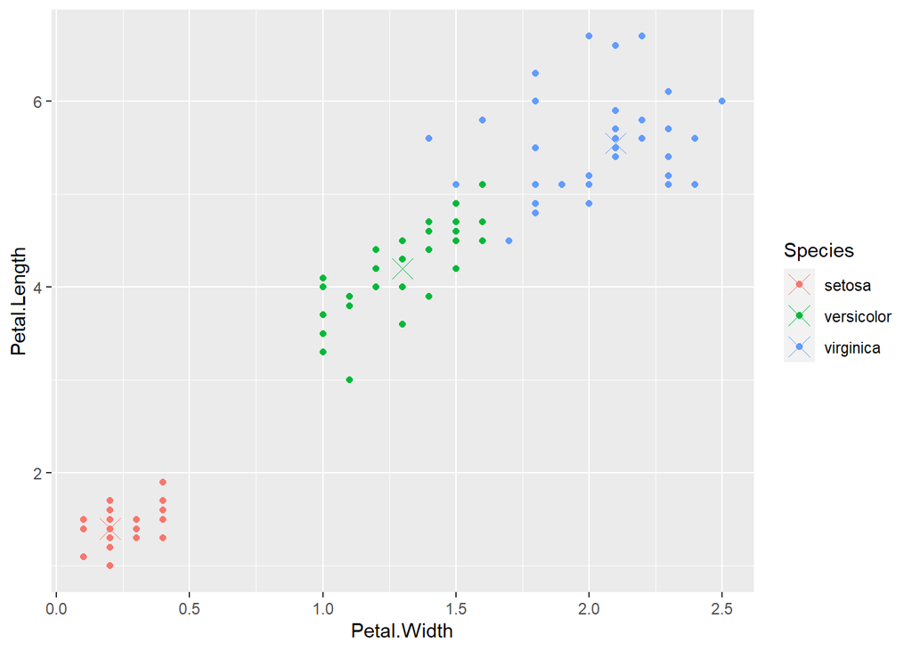

```r
irisP <- classCenter(training[,c(3,4)], training$Species, modFit$finalModel$prox)
irisP <- as.data.frame(irisP); irisP$Species <- rownames(irisP)
p <- qplot(Petal.Width, Petal.Length, col=Species,data=training)
p + geom_point(aes(x=Petal.Width,y=Petal.Length,col=Species),size=5,shape=4,data=irisP)
```

- Each of the `X` marks are the centers for each `species`

#### Predicting new values

```r
pred <- predict(modFit,testing)
table(pred,testing$Species)
```

```
##
## pred         setosa versicolor virginica
##   setosa         15          0         0
##   versicolor      0         13         1
##   virginica       0          2        14
```

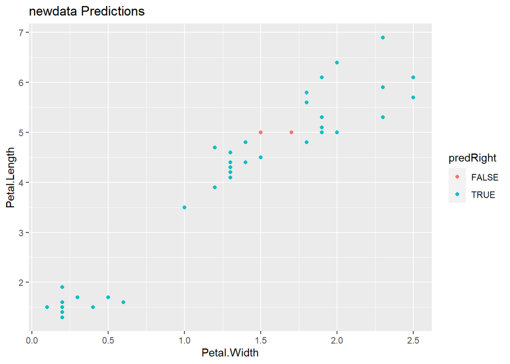

```r
testing$predRight <- pred==testing$Species
qplot(Petal.Width,Petal.Length,colour=predRight,data=testing,main="newdata Predictions")
```

#### Notes and further resources

**Notes**:

- Random forests are usually one of the two top performing algorithms along with boosting in prediction contests.
- Random forests are difficult to interpret but often very accurate.
- Care should be taken to avoid overfitting (see [rfcv](http://cran.r-project.org/web/packages/randomForest/randomForest.pdf) funtion)

**Further resources**:

- [Random forests](http://www.stat.berkeley.edu/~breiman/RandomForests/cc_home.htm)
- [Random forest Wikipedia](http://en.wikipedia.org/wiki/Random_forest)
- [Elements of Statistical Learning](http://www-stat.stanford.edu/~tibs/ElemStatLearn/)

### 2.) Boosting

- Basic idea is that 1. take lots of (possibly) weak predictors 2. Weight them and add them up 3. Get a stronger predictor

#### Boosting in R

- Boosting can be used with any subset of classifiers
- One large subclass is [gradient boosting](http://en.wikipedia.org/wiki/Gradient_boosting)
- R has multiple boosting libraries. Differences include the choice of basic classification functions and combination rules.
  - [gbm](http://cran.r-project.org/web/packages/gbm/index.html) - boosting with trees.
  - [mboost](http://cran.r-project.org/web/packages/mboost/index.html) - model based boosting
  - [ada](http://cran.r-project.org/web/packages/ada/index.html) - statistical boosting based on [additive logistic regression](http://projecteuclid.org/DPubS?service=UI&version=1.0&verb=Display&handle=euclid.aos/1016218223)
  - [gamBoost](http://cran.r-project.org/web/packages/GAMBoost/index.html) for boosting generalized additive models
- Most of these are available in the caret package

#### Wage example

```r
library(ISLR); data(Wage); library(ggplot2); library(caret);

Wage <- subset(Wage,select=-c(logwage))
inTrain <- createDataPartition(y=Wage$wage,
                              p=0.7, list=FALSE)
training <- Wage[inTrain,]; testing <- Wage[-inTrain,]

# model fit
modFit <- train(wage ~ ., method="gbm",data=training,verbose=FALSE)
print(modFit)
```

```
## Stochastic Gradient Boosting
##
## 2102 samples
##    9 predictor
##
## No pre-processing
## Resampling: Bootstrapped (25 reps)
## Summary of sample sizes: 2102, 2102, 2102, 2102, 2102, 2102, ...
## Resampling results across tuning parameters:
##
##   interaction.depth  n.trees  RMSE      Rsquared   MAE
##   1                   50      34.12723  0.3245969  23.37920
##   1                  100      33.53578  0.3355700  22.91888
##   1                  150      33.45570  0.3374800  22.89096
##   2                   50      33.56145  0.3359561  22.90209
##   2                  100      33.43746  0.3381607  22.86804
##   2                  150      33.53570  0.3351870  23.00280
##   3                   50      33.43749  0.3389133  22.83795
##   3                  100      33.56273  0.3342006  23.01337
##   3                  150      33.75708  0.3278442  23.21525
##
## Tuning parameter 'shrinkage' was held constant at a value of 0.1
##
## Tuning parameter 'n.minobsinnode' was held constant at a value of 10
## RMSE was used to select the optimal model using the smallest value.
## The final values used for the model were n.trees = 100, interaction.depth =
##  2, shrinkage = 0.1 and n.minobsinnode = 10.
```

- Quick plot to show results

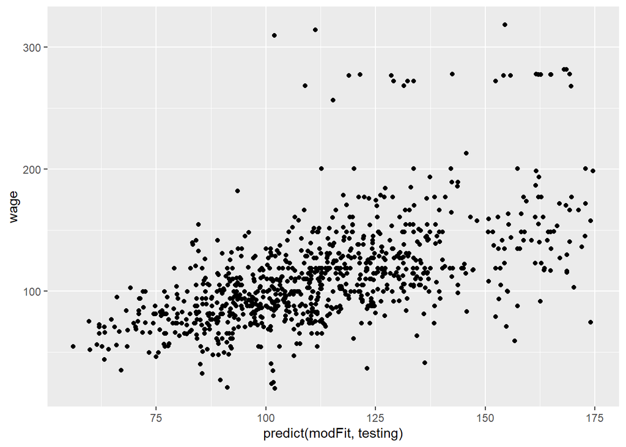

```r
qplot(predict(modFit,testing),wage,data=testing)
```

- They’re mostly on diagonal axis, although it’s clear that not all variance is explained.

#### Notes and further reading

- A couple of nice tutorials for boosting
  - Freund and Shapire - http://www.cc.gatech.edu/~thad/6601-gradAI-fall2013/boosting.pdf
  - Ron Meir- http://webee.technion.ac.il/people/rmeir/BoostingTutorial.pdf
- Boosting, random forests, and model ensembling are the most common tools that win Kaggle and other prediction contests.
  - http://www.netflixprize.com/assets/GrandPrize2009_BPC_BigChaos.pdf
  - https://kaggle2.blob.core.windows.net/wiki-files/327/09ccf652-8c1c-4a3d-b979-ce2369c985e4/Willem%20Mestrom%20-%20Milestone%201%20Description%20V2%202.pdf